# DS 202 Lab 2: Chocolate tasting

```r
summaries = tapply(choco$Rating, choco$CocoaPercent, summary)
head(summaries, n=5)
```

```
## $`42`
##    Min. 1st Qu.  Median    Mean 3rd Qu.    Max.
##    2.75    2.75    2.75    2.75    2.75    2.75
##
## $`46`
##    Min. 1st Qu.  Median    Mean 3rd Qu.    Max.
##    2.75    2.75    2.75    2.75    2.75    2.75
##
## $`50`
##    Min. 1st Qu.  Median    Mean 3rd Qu.    Max.
##    3.75    3.75    3.75    3.75    3.75    3.75
##
## $`53`
##    Min. 1st Qu.  Median    Mean 3rd Qu.    Max.
##       2       2       2       2       2       2
##
## $`55`
##    Min. 1st Qu.  Median    Mean 3rd Qu.    Max.
##   2.250   2.688   2.750   2.859   3.062   3.500
```

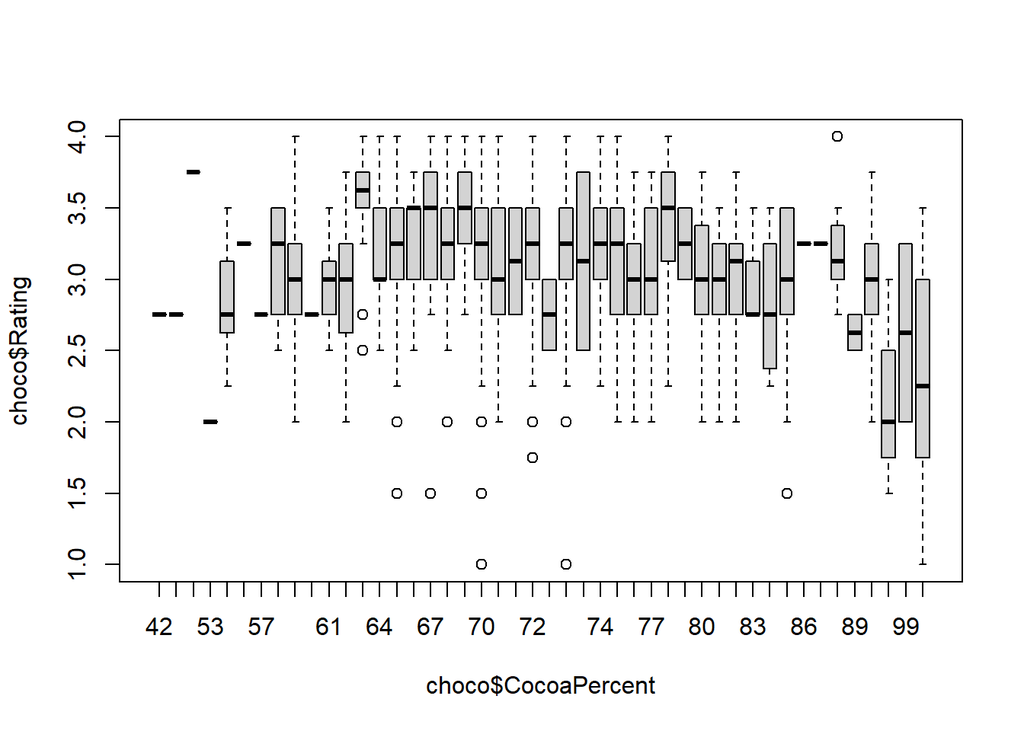

```r
boxplot(choco$Rating~choco$CocoaPercent,)
```

4. How do different bean origins compare in terms of the flavor of chocolates? Are beans from some places better than the other? Create both numerical and graphical summaries, and explain.

Do to a very large number of characteristics, the flavor of the beans was hard to predict.

```r
flavor <- table(choco$Characteristics2)
length(flavor)
```

```
## [1] 528
```

```r
summary(as.numeric(flavor))
```

```
##    Min. 1st Qu.  Median    Mean 3rd Qu.    Max.
##   1.000   1.000   1.000   4.517   3.000 124.000
```

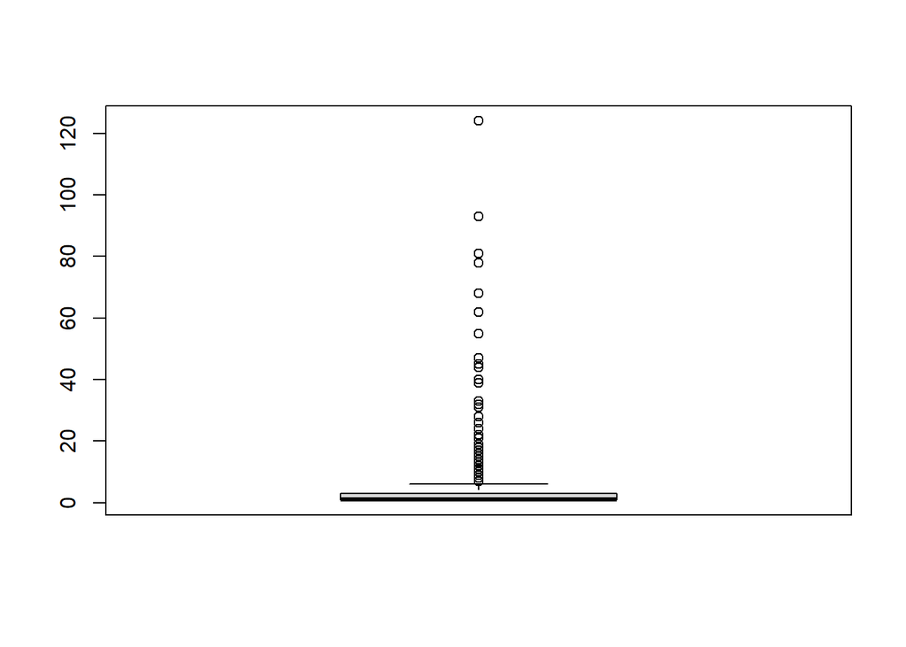

```r
boxplot(flavor)
```

5. If you work on this lab by yourself, brainstorm two analyses you would like to perform. If you work with a teammate, brainstorm at least three analyses with your teammate. Describe in plain language what comparisons are you making. Create suitable numerical and graphical summaries for your analyses. Describe the results.

```r
summaries = tapply(choco$CocoaPercent, choco$CountryBeanOrigin, summary)
select10 <- head(summaries, n=10)
select10
```

```
## $Australia
##    Min. 1st Qu.  Median    Mean 3rd Qu.    Max.
##    67.0    68.5    70.0    69.0    70.0    70.0
##
## $Belize
##    Min. 1st Qu.  Median    Mean 3rd Qu.    Max.
##   64.00   70.00   72.00   72.86   75.00   90.00
##
## $Blend
##    Min. 1st Qu.  Median    Mean 3rd Qu.    Max.
##   46.00   67.00   70.00   71.99   75.00  100.00
##
## $Bolivia
##    Min. 1st Qu.  Median    Mean 3rd Qu.    Max.
##   60.00   70.00   70.00   71.58   74.00   90.00
##
## $Brazil
##    Min. 1st Qu.  Median    Mean 3rd Qu.    Max.
##    50.0    70.0    70.0    71.4    75.0    85.0
##
## $Burma
##    Min. 1st Qu.  Median    Mean 3rd Qu.    Max.
##      70      70      70      70      70      70
##
## $Cameroon
##    Min. 1st Qu.  Median    Mean 3rd Qu.    Max.
##   68.00   69.00   70.00   69.33   70.00   70.00
##
## $Colombia
##    Min. 1st Qu.  Median    Mean 3rd Qu.    Max.
##    53.0    70.0    70.0    70.8    72.0    88.0
##
## $Congo
##    Min. 1st Qu.  Median    Mean 3rd Qu.    Max.
##   65.00   68.00   70.00   70.45   71.00   82.00
##
## $`Costa Rica`
##    Min. 1st Qu.  Median    Mean 3rd Qu.    Max.
##   58.00   70.00   70.00   71.51   73.50   82.00
```

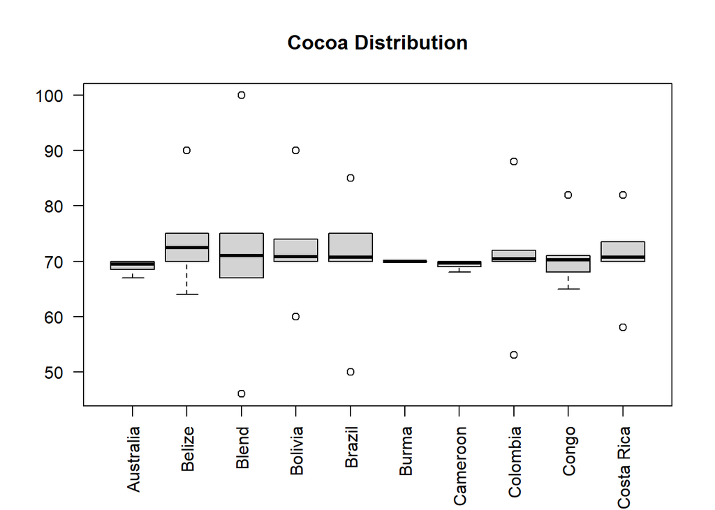

```r
boxplot(select10, main="Cocoa Distribution", las=2)
```

For my second analysis, I am determining if what ingredients influence ratings the most. Based on the below information, it appears that certain ingredients do play a role in the ratings. Each chocolate is different so, it would have a varying rating

```r
summaries = tapply(choco$Rating, choco$Ingredients, summary)
select10 <- head(summaries, n=10)
select10
```

```
## $`1- B`
##    Min. 1st Qu.  Median    Mean 3rd Qu.    Max.
##   2.500   2.812   3.000   2.958   3.000   3.500
##
## $`2- B,C`
##    Min. 1st Qu.  Median    Mean 3rd Qu.    Max.
##       3       3       3       3       3       3
##
## $`2- B,S`
##    Min. 1st Qu.  Median    Mean 3rd Qu.    Max.
##   2.000   3.000   3.250   3.228   3.500   4.000
##
## $`2- B,S*`
##    Min. 1st Qu.  Median    Mean 3rd Qu.    Max.
##    2.00    2.50    3.00    2.96    3.25    3.50
##
## $`3- B,S*,C`
##    Min. 1st Qu.  Median    Mean 3rd Qu.    Max.
##   2.750   2.750   2.750   2.938   3.062   3.500
##
## $`3- B,S*,Sa`
##    Min. 1st Qu.  Median    Mean 3rd Qu.    Max.
##     2.5     2.5     2.5     2.5     2.5     2.5
##
## $`3- B,S,C`
##    Min. 1st Qu.  Median    Mean 3rd Qu.    Max.
##   1.500   3.000   3.250   3.276   3.500   4.000
##
## $`3- B,S,L`
##    Min. 1st Qu.  Median    Mean 3rd Qu.    Max.
##   1.500   2.625   2.875   2.688   3.000   3.250
##
## $`3- B,S,V`
##    Min. 1st Qu.  Median    Mean 3rd Qu.    Max.
##   2.500   3.000   3.500   3.167   3.500   3.500
##
## $`4- B,S*,C,L`
##    Min. 1st Qu.  Median    Mean 3rd Qu.    Max.
##   2.750   2.812   2.875   2.875   2.938   3.000
```

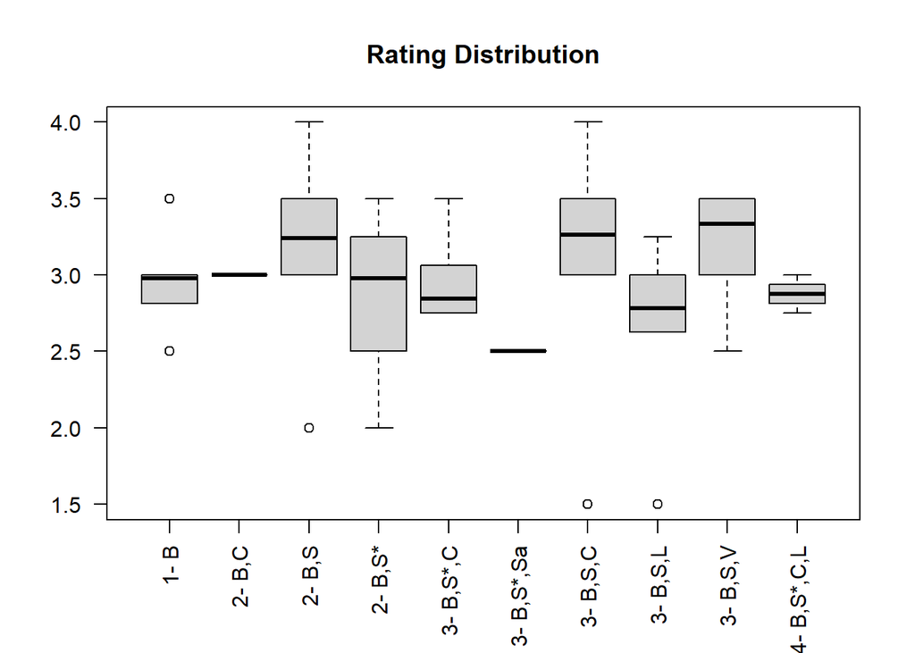

```r
boxplot(select10, main="Rating Distribution", las=2)
```